# COMPSCIX 415.2 Homework 4 - Cuesta

## 5.6.7 Exercises

#### Come up with another approach that will give you the same output as not_cancelled %>% count(dest) and not_cancelled %>% count(tailnum, wt = distance) (without using count()).

```r
library(nycflights13)
library(tidyverse)
flights
```

```
## # A tibble: 336,776 x 19
##     year month   day dep_time sched_dep_time dep_delay arr_time
##    <int> <int> <int>    <int>          <int>     <dbl>    <int>
##  1  2013     1     1      517            515         2      830
##  2  2013     1     1      533            529         4      850
##  3  2013     1     1      542            540         2      923
##  4  2013     1     1      544            545        -1     1004
##  5  2013     1     1      554            600        -6      812
##  6  2013     1     1      554            558        -4      740
##  7  2013     1     1      555            600        -5      913
##  8  2013     1     1      557            600        -3      709
##  9  2013     1     1      557            600        -3      838
## 10  2013     1     1      558            600        -2      753
## # ... with 336,766 more rows, and 12 more variables: sched_arr_time <int>,
## #   arr_delay <dbl>, carrier <chr>, flight <int>, tailnum <chr>,
## #   origin <chr>, dest <chr>, air_time <dbl>, distance <dbl>, hour <dbl>,
## #   minute <dbl>, time_hour <dttm>
```

```r
flights %>%
  group_by(dest) %>%
  summarise(n = length(dest))
```

```
## # A tibble: 105 x 2
##    dest      n
##    <chr> <int>
##  1 ABQ     254
##  2 ACK     265
##  3 ALB     439
##  4 ANC       8
##  5 ATL   17215
##  6 AUS    2439
##  7 AVL     275
##  8 BDL     443
##  9 BGR     375
## 10 BHM     297
## # ... with 95 more rows
```

#### Look at the number of cancelled flights per day. Is there a pattern? Is the proportion of cancelled flights related to the average delay?

```r
results <-
  flights %>%
  mutate(canceled_flights = (is.na(arr_delay) | is.na(dep_delay))) %>%
  group_by(year, month, day) %>%
  summarise(prop_canceled = mean(canceled_flights),
            avg_delay = mean(dep_delay, na.rm = TRUE))

results
```

```
## # A tibble: 365 x 5
## # Groups:   year, month [?]
##     year month   day prop_canceled avg_delay
##    <int> <int> <int>         <dbl>     <dbl>
##  1  2013     1     1       0.0131      11.5
##  2  2013     1     2       0.0159      13.9
##  3  2013     1     3       0.0153      11.0
##  4  2013     1     4       0.00765      8.95
##  5  2013     1     5       0.00417      5.73
##  6  2013     1     6       0.00361      7.15
##  7  2013     1     7       0.00322      5.42
##  8  2013     1     8       0.00779      2.55
##  9  2013     1     9       0.00998      2.28
## 10  2013     1    10       0.00322      2.84
## # ... with 355 more rows
```

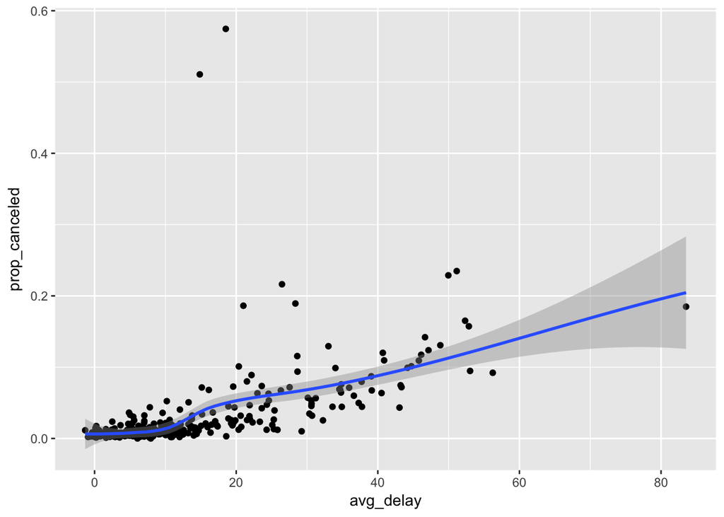

```r
 ggplot(results, aes(x = avg_delay, prop_canceled)) +
  geom_point() +
  geom_smooth()
```

Yes, there are a correlation between the number of flights cancelled per day and the average delay.

#### What does the sort argument to count() do. When might you use it?

The sort argument to count sorts the results in order. It can be used this anytime we count and the sort.

## 10.5 Exercises

#### How can you tell if an object is a tibble? (Hint: try printing mtcars, which is a regular data frame).

Tibbles have a refined print method that shows only the first 10 rows and all the columns that fit on screen.

#### Compare and contrast the following operations on a data.frame and equivalent tibble. What is different? Why might the default data frame behaviours cause you frustration?

```r
df <- data.frame(abc = 1, xyz = "a")
df$x
```

```
## [1] a
## Levels: a
```

```r
df[, "xyz"]
```

```
## [1] a
## Levels: a
```

```r
df[, c("abc", "xyz")]
```

```
##   abc xyz
## 1   1   a
```

```r
tbl <- as_tibble(df)
tbl$x
```

[output not shown]

```r
tbl[, "xyz"]
```

```
## # A tibble: 1 x 1
##   xyz
##   <fct>
## 1 a
```

```r
tbl[, c("abc", "xyz")]
```

```
## # A tibble: 1 x 2
##     abc xyz
##   <dbl> <fct>
## 1     1 a
```

#### If you have the name of a variable stored in an object, e.g. var <- “mpg”, how can you extract the reference variable from a tibble?

You can use the double bracket, like df[[var]]. You cannot use the dollar sign, because df$var would look for a column named var

#### What option controls how many additional column names are printed at the footer of a tibble?

The option n_extra determines the number of extra columns to print information for

## Section 12.3.3

#### Why does this code fail?

table4a %>% gather(1999, 2000, key = “year”, value = “cases”)

Because the column names cannot be numbers

#### Why does spreading this tibble fail? How could you add a new column to fix the problem?

```r
people <- tribble(
  ~name,             ~key,    ~value,
  #-----------------|--------|------
  "Phillip Woods",   "age",       45,
  "Phillip Woods",   "height",   186,
  "Phillip Woods",   "age",       50,
  "Jessica Cordero", "age",       37,
  "Jessica Cordero", "height",   156
)
```

Spreading the data frame fails because there are two rows with “age” for “Phillip Woods”.

#### Tidy the simple tibble below. Do you need to spread or gather it? What are the variables?

```r
preg <- tribble(
  ~pregnant, ~male, ~female,
  "yes",     NA,    10,
  "no",      20,    12
)
```

We need to gather pregnant: logical (“yes”, “no”) female: logical count: integer

## Section 12.4.3

#### What do the extra and fill arguments do in separate()? Experiment with the various options for the following two toy datasets.

```r
?separate
```

The extra argument tells separate what to do if there are too many pieces, and the fill argument if there aren’t enough.

```r
tibble(data =  c("apple,raspberry,tomato","cucumber,lime,lettuce","banana,squash,orange")) %>% separate(data, c("red","green","yellow"))
```

```
## # A tibble: 3 x 3
##   red      green     yellow
##   <chr>    <chr>     <chr>
## 1 apple    raspberry tomato
## 2 cucumber lime      lettuce
## 3 banana   squash    orange
```

#### Both unite() and separate() have a remove argument. What does it do? Why would you set it to FALSE?

Remove when set to FALSE includes the input column in the output

```r
tibble(data =  c("apple,raspberry,tomato","cucumber,lime,lettuce","banana,squash,orange")) %>% separate(data, c("red","green","yellow"),remove = FALSE)
```

```
## # A tibble: 3 x 4
##   data                   red      green     yellow
##   <chr>                  <chr>    <chr>     <chr>
## 1 apple,raspberry,tomato apple    raspberry tomato
## 2 cucumber,lime,lettuce  cucumber lime      lettuce
## 3 banana,squash,orange   banana   squash    orange
```

I think it would be useful for validation.